# Projekt_ADWBD_AD

Andrzej Danieluk

2026-02-04

## Wstęp

W tym projekcie będę analizować zbiór danych `Dane 38`. Poniżej znajduje się konfiguracja środowiska oraz wczytanie danych.

```r
knitr::opts_chunk$set(echo = TRUE)
dane = read.csv("Dane 38 .csv")
```

```r
library(MASS)
library(glmnet)
library(caret)
```

```r
head(dane)
```

```
##             A         B          C Class
## 1  0.75050701 1.7349404  0.8102476     1
## 2  0.36116070 0.8095716  0.6108265     1
## 3 -0.66572856 0.7863110  2.3718396     1
## 4  0.34769076 0.7954377 -0.1578692     1
## 5  0.15001639 1.3250694  1.0256104     1
## 6 -0.01620116 0.9800666  1.2234659     1
```

```r
str(dane)
```

```
## 'data.frame':    474 obs. of  4 variables:
##  $ A    : num  0.751 0.361 -0.666 0.348 0.15 ...
##  $ B    : num  1.735 0.81 0.786 0.795 1.325 ...
##  $ C    : num  0.81 0.611 2.372 -0.158 1.026 ...
##  $ Class: int  1 1 1 1 1 1 1 1 1 1 ...
```

```r
#należy przekształcić zmienną class na factor
dane$Class = as.factor(dane$Class)
str(dane)
```

```
## 'data.frame':    474 obs. of  4 variables:
##  $ A    : num  0.751 0.361 -0.666 0.348 0.15 ...
##  $ B    : num  1.735 0.81 0.786 0.795 1.325 ...
##  $ C    : num  0.81 0.611 2.372 -0.158 1.026 ...
##  $ Class: Factor w/ 3 levels "1","2","3": 1 1 1 1 1 1 1 1 1 1 ...
```

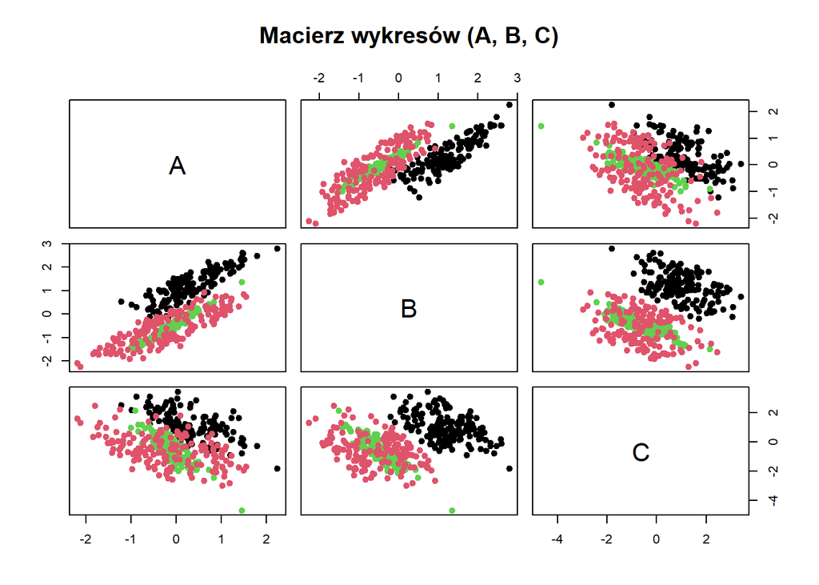

```r
pairs(dane[1:3], col = dane$Class, pch = 19, main = "Macierz wykresów (A, B, C)")
```

```r
# 1. Budowa modelu LDA
model_lda = lda(Class ~ ., data = dane)
model_lda
```

```
## Call:
## lda(Class ~ ., data = dane)
##
## Prior probabilities of groups:
##         1         2         3
## 0.3206751 0.3333333 0.3459916
##
## Group means:
##             A          B          C
## 1  0.32955164  1.2273384  1.0162550
## 2 -0.18824844 -0.5961125 -0.5833564
## 3 -0.06917451 -0.4929526 -0.5468835
##
## Coefficients of linear discriminants:
##          LD1        LD2
## A  1.4361259  2.6684371
## B -2.7612569 -1.1865513
## C -0.6794942  0.5547008
##
## Proportion of trace:
##    LD1    LD2
## 0.9987 0.0013
```

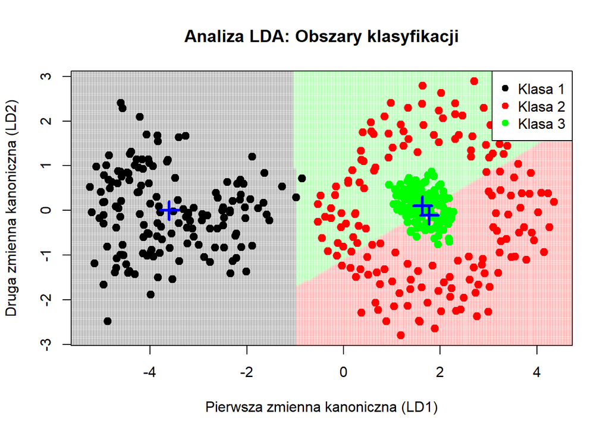

```r
# 2. Obliczenie zmiennych kanonicznych (LD1, LD2)
predykcja = predict(model_lda)
ld1 = predykcja$x[,1]
ld2 = predykcja$x[,2]

# 3. Przygotowanie siatki do narysowania obszarów
siatka_n = 200
x_min = min(ld1) - 1; x_max = max(ld1) + 1
y_min = min(ld2) - 1; y_max = max(ld2) + 1

siatka_x = seq(x_min, x_max, length.out = siatka_n)
siatka_y = seq(y_min, y_max, length.out = siatka_n)
siatka = expand.grid(LD1 = siatka_x, LD2 = siatka_y)

# --- Obliczanie klas dla tła ---
# W przestrzeni zmiennych kanonicznych klasyfikujemy do najbliższego środka grupy.
# Obliczamy środki (średnie) dla każdej klasy w przestrzeni LD1 i LD2
srednie_gr = aggregate(cbind(ld1, ld2) ~ dane$Class, FUN = mean)
srednie_mat = as.matrix(srednie_gr[,2:3])
rownames(srednie_mat) = srednie_gr[,1]

# Funkcja pomocnicza do znalezienia najbliższej klasy (odległość euklidesowa)
klasyfikuj_punkt = function(x, y) {
  odleglosci = numeric(nrow(srednie_mat))
  for(i in 1:nrow(srednie_mat)) {
    # Odległość punktu od środka i-tej klasy
    odleglosci[i] = sqrt((x - srednie_mat[i,1])^2 + (y - srednie_mat[i,2])^2)
  }
  return(as.numeric(rownames(srednie_mat)[which.min(odleglosci)]))
}

# Klasyfikujemy każdy punkt siatki
klasy_tla = mapply(klasyfikuj_punkt, siatka$LD1, siatka$LD2)

# 4. Rysowanie wykresu

# Definiujemy kolory
kolory_tlo = c(rgb(0,0,0,0.1), rgb(1,0,0,0.1), rgb(0,1,0,0.1)) # Szary, Czerwony, Zielony (jasne)
kolory_pkt = c("black", "red", "green")

# Pusty wykres (setup)
plot(ld1, ld2, type="n",
     main="Analiza LDA: Obszary klasyfikacji",
     xlab="Pierwsza zmienna kanoniczna (LD1)",
     ylab="Druga zmienna kanoniczna (LD2)")

# Rysujemy tło (obszary)
points(siatka$LD1, siatka$LD2, col=kolory_tlo[klasy_tla], pch=15, cex=0.5)

# Rysujemy nasze dane (punkty)
points(ld1, ld2, col=kolory_pkt[dane$Class], pch=19, cex=1.2)

# Rysujemy środki grup
points(srednie_mat[,1], srednie_mat[,2], col="blue", pch=3, lwd=3, cex=2)

# Legenda
legend("topright", legend=c("Klasa 1", "Klasa 2", "Klasa 3"),
       col=kolory_pkt, pch=19, bg="white")
```

## Wnioski z analizy LDA i koncepcja modelu nieliniowego

### Diagnoza problemu

Analiza przeprowadzona w punkcie A ujawniła istotne ograniczenie metody LDA. Jak widać na powyższym wykresie, algorytm ten próbuje rozdzielić klasy za pomocą **linii prostych** (cięć liniowych).

W przypadku naszych danych: 1. **Klasa 1 (Czarne punkty)** jest liniowo separowalna od pozostałych i LDA radzi sobie z nią poprawnie. 2. **Klasa 2 i 3 (Zielone i Czerwone punkty)** tworzą strukturę nieliniową – tzw. “pierścień Saturna”, gdzie jedna klasa otacza drugą. Żadna prosta linia nie jest w stanie ich poprawnie rozdzielić, co skutkuje błędną klasyfikacją (widoczny podział skupiska na pół).

### Plan rozwiązania: Podejście RBF (Radial Basis Functions)

Aby rozwiązać ten problem, w podpunkcie B zastosujemy podejście nieliniowe, oparte na **funkcjach bazowych (RBF)**.

Zamiast operować na surowych współrzędnych $(A, B)$, przetransformujemy przestrzeń danych, opierając się na **odległościach od punktów charakterystycznych (centrów)**:

1. **Wyznaczenie centrów ($m_i$):** Użyjemy algorytmu *k-means*, aby znaleźć w przestrzeni danych kilka punktów referencyjnych (reprezentantów lokalnych skupisk).
2. **Nowe zmienne:** Dla każdego punktu danych obliczymy jego odległość od tych centrów. Dzięki temu informacja “jestem w środku pierścienia” zostanie zamieniona na liczbę (mała odległość od centrum wewnętrznego).
3. **Regresja z karą:** Zbudujemy model regresji logistycznej na tych nowych zmiennych. Aby uniknąć nadmiernego dopasowania (overfittingu) i wybrać tylko najważniejsze centra, zastosujemy **regularyzację (karę)**.

Dzięki temu podejściu spodziewamy się uzyskać granice decyzyjne w kształcie krzywych (okręgów), które naturalnie oddzielą “pierścień” od “jądra”.

## Podpunkt B: Regresja Logistyczna z funkcjami bazowymi (RBF)

W tym kroku stosujemy nieliniową transformację danych. Jako zmienne objaśniające przyjmujemy odległości punktów od wyznaczonych centrów $m_i$. Pozwoli to na wyznaczenie zakrzywionych granic decyzyjnych (np. oddzielenie pierścienia od środka).

```r
# 1. Definicja funkcji bazowej (Odległość Euklidesowa)
# x - macierz danych (punkty), m - wektor współrzędnych centrum
phi_dist = function(x, m) {
  # Obliczamy odległość każdego wiersza x od punktu m
  return(sqrt((x[,1] - m[1])^2 + (x[,2] - m[2])^2))
}

# 2. Znalezienie optymalnych centrów m_i
# Skorzystamy z algorytmu k-means, aby znaleźć 'k' punktów, które najlepiej
# pokrywają nasze dane. Sprawdzimy kilka wariantów, aby zminimalizować błąd.

set.seed(123)
best_acc = 0
best_centers = NULL
best_k = 0

# Testujemy od 3 do 10 centrów (staramy się, żeby było ich mało, ale skutecznie)
# Zmiennych A i B używamy do szukania centrów
dane_xy = dane[, c("A", "B")]

for(k in 3:10) {
  km = kmeans(dane_xy, centers = k, nstart = 10)
  centers = km$centers

  # Tworzymy macierz nowych zmiennych (odległości od centrów)
  X_temp = matrix(0, nrow = nrow(dane), ncol = k)
  for(i in 1:k) {
    X_temp[,i] = phi_dist(dane_xy, centers[i,])
  }

  # Szybki test modelu (cv.glmnet dobiera optymalną karę lambda)
  fit = cv.glmnet(X_temp, dane$Class, family = "multinomial", type.measure = "class")

  # Sprawdzamy dokładność (1 - błąd)
  preds = predict(fit, newx = X_temp, s = "lambda.min", type = "class")
  acc = mean(preds == dane$Class)

  # Jeśli to najlepszy wynik, zapisujemy go
  if(acc > best_acc) {
    best_acc = acc
    best_centers = centers
    best_k = k
    best_model = fit
  }
}

print(paste("Wybrano liczbę centrów:", best_k))
```

```
## [1] "Wybrano liczbę centrów: 9"
```

```r
print(paste("Dokładność modelu:", round(best_acc * 100, 2), "%"))
```

```
## [1] "Dokładność modelu: 92.19 %"
```

```r
print("Współrzędne centrów m_i:")
```

```
## [1] "Współrzędne centrów m_i:"
```

```r
print(best_centers)
```

```
##             A           B
## 1  0.95992223  0.23406935
## 2 -0.44094481 -0.97076801
## 3 -1.28773274 -1.50447596
## 4  1.43915596  2.29988002
## 5  0.25083431 -0.03782586
## 6 -0.45092322  0.11428594
## 7  0.82666249  1.72075859
## 8  0.13648188  1.08361830
## 9 -0.07741711 -0.53584080
```

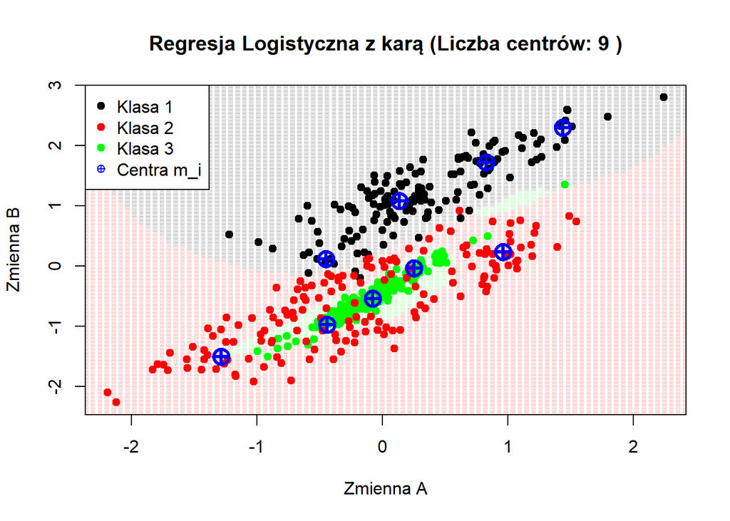

```r
# 3. Przygotowanie danych do wykresu (Siatka)
# Tworzymy siatkę punktów (A, B)
x_min = min(dane$A) - 0.5; x_max = max(dane$A) + 0.5
y_min = min(dane$B) - 0.5; y_max = max(dane$B) + 0.5
siatka_n = 100
grid_x = seq(x_min, x_max, length.out = siatka_n)
grid_y = seq(y_min, y_max, length.out = siatka_n)
siatka = expand.grid(A = grid_x, B = grid_y)

# Transformujemy siatkę na odległości od naszych WYBRANYCH centrów
X_siatka = matrix(0, nrow = nrow(siatka), ncol = best_k)
for(i in 1:best_k) {
  X_siatka[,i] = phi_dist(siatka, best_centers[i,])
}

# 4. Predykcja dla tła
pred_siatka = predict(best_model, newx = X_siatka, s = "lambda.min", type = "class")
klasy_tla = as.numeric(pred_siatka)

# 5. Rysowanie wykresu
kolory_tlo = c(rgb(0,0,0,0.1), rgb(1,0,0,0.1), rgb(0,1,0,0.1)) # Szary, Czerwony, Zielony
kolory_pkt = c("black", "red", "green")

plot(dane$A, dane$B, type="n",
     main = paste("Regresja Logistyczna z karą (Liczba centrów:", best_k, ")"),
     xlab = "Zmienna A", ylab = "Zmienna B")

# Tło
points(siatka$A, siatka$B, col = kolory_tlo[klasy_tla], pch = 15, cex = 0.6)

# Punkty danych
points(dane$A, dane$B, col = kolory_pkt[dane$Class], pch = 19, cex = 1)

# Pokażmy gdzie algorytm ustawił centra (niebieskie krzyżyki)
points(best_centers[,1], best_centers[,2], col="blue", pch=10, cex=2, lwd=3)

legend("topleft", legend=c("Klasa 1", "Klasa 2", "Klasa 3", "Centra m_i"),
       col=c("black", "red", "green", "blue"), pch=c(19,19,19,10), bg="white")
```

## Porównanie błędów klasyfikacji (Kroswalidacja)

W tej sekcji porównuję skuteczność obu modeli (LDA vs RBF Log-Reg) stosując dwie metody walidacji:

1. **LOOCV (n-krotna):** Leave-One-Out Cross Validation. Najdokładniejsza metoda, polegająca na trenowaniu modelu na $n-1$ obserwacjach i testowaniu na jednej, powtarzana dla wszystkich obserwacji.
2. **10-krotna (10-fold CV):** Dzieli dane losowo na 10 części. Jest to standard w analizie danych.

Dla modelu RBF zastosowano optymalizację obliczeniową: najpierw wyznaczamy optymalną wartość parametru lambda na całym zbiorze, a następnie używamy tej ustalonej wartości w pętlach walidacyjnych. Pozwala to znacznie skrócić czas wykonywania walidacji LOOCV bez utraty poprawności metodologicznej.

```r
# 1. Walidacja LDA (z pakietu caret)
set.seed(123)
ctrl_loocv = trainControl(method = "LOOCV")
ctrl_cv10  = trainControl(method = "cv", number = 10)

lda_loocv = train(Class ~ ., data = dane, method = "lda", trControl = ctrl_loocv)
lda_cv10  = train(Class ~ ., data = dane, method = "lda", trControl = ctrl_cv10)

err_lda_loocv = 1 - lda_loocv$results$Accuracy
err_lda_cv10  = 1 - lda_cv10$results$Accuracy

# 2. Walidacja RBF + Regresja (Implementacja własna)

# Krok A: Ustalamy parametry raz, żeby nie liczyć ich w pętli
set.seed(123)
K_CENTERS = if(exists("best_k")) best_k else 6
# Szukamy centrów na całych danych (dla ustalenia lambdy)
km_init = kmeans(dane[, c("A", "B")], centers = K_CENTERS, nstart = 10)

# Transformacja
X_all_rbf = matrix(0, nrow = nrow(dane), ncol = K_CENTERS)
for(i in 1:K_CENTERS) X_all_rbf[,i] = phi_dist(dane[, c("A", "B")], km_init$centers[i,])

# Znajdujemy najlepszą lambdę
init_cv = cv.glmnet(X_all_rbf, dane$Class, family = "multinomial", type.measure = "class")
BEST_LAMBDA = init_cv$lambda.min

# Funkcja pomocnicza: test RBF
evaluate_rbf_fast = function(train_idx, test_idx) {
  d_train = dane[train_idx, ]
  d_test  = dane[test_idx, ]

  # 1. K-means na zbiorze treningowym
  km = kmeans(d_train[, c("A", "B")], centers = K_CENTERS, nstart = 1)
  centers = km$centers

  # 2. Transformacja
  X_train = matrix(0, nrow = nrow(d_train), ncol = K_CENTERS)
  X_test  = matrix(0, nrow = nrow(d_test),  ncol = K_CENTERS)
  for(i in 1:K_CENTERS) {
    X_train[,i] = phi_dist(d_train[, c("A", "B")], centers[i,])
    X_test[,i]  = phi_dist(d_test[, c("A", "B")],  centers[i,])
  }

  # 3. Model GLMNET z lambdą
  fit = glmnet(X_train, d_train$Class, family = "multinomial", lambda = BEST_LAMBDA)

  # 4. Predykcja
  pred = predict(fit, newx = X_test, type = "class")

  return(sum(pred != d_test$Class))
}

# Pętla LOOCV
n = nrow(dane)
errors_loocv = 0
set.seed(123)

for(i in 1:n) {
  errors_loocv = errors_loocv + evaluate_rbf_fast(train_idx = -i, test_idx = i)
}
err_rbf_loocv = errors_loocv / n

# Pętla 10-fold CV
folds = createFolds(dane$Class, k = 10, list = TRUE, returnTrain = FALSE)
errors_cv10 = 0
for(f in 1:10) {
  idx_test = folds[[f]]
  idx_train = setdiff(1:n, idx_test)
  errors_cv10 = errors_cv10 + evaluate_rbf_fast(train_idx = idx_train, test_idx = idx_test)
}
err_rbf_cv10 = errors_cv10 / n

# Wyświetlenie wyników
wyniki = data.frame(
  Metoda = c("LDA (Liniowa)", "RBF (Nieliniowa)"),
  LOOCV_Blad = c(err_lda_loocv, err_rbf_loocv),
  CV10_Blad = c(err_lda_cv10, err_rbf_cv10)
)
knitr::kable(wyniki, digits = 4, caption = "Porównanie błędów klasyfikacji")
```

Porównanie błędów klasyfikacji

| Metoda | LOOCV_Blad | CV10_Blad |
| --- | --- | --- |
| LDA (Liniowa) | 0.2637 | 0.2639 |
| RBF (Nieliniowa) | 0.0970 | 0.0992 |

## Podsumowanie i Wnioski Końcowe

Celem projektu było porównanie skuteczności metod liniowych i nieliniowych w klasyfikacji danych o złożonej strukturze geometrycznej (tzw. struktura pierścieniowa).

**Konkluzja:** W przypadku danych o strukturze koncentrycznej (pierścieniowej), metody nieliniowe (takie jak RBF) są znacznie bardziej adekwatne i skuteczne niż klasyczne metody liniowe typu LDA.